# Homework 4

## Decision Tree

```r
prs <- read.csv("C:/Users/sec/Desktop/교과목들/데이터 과학/PRSA_data.csv")
library(tidyr)
library(caret)
library(lubridate)
```

```r
library(ggplot2)
library(reshape2)
library(ROCR)
library(rpart)
library(rpart.plot)
library(class)
library(kknn)
```

자료 구조 확인

```r
str(prs)
```

```
## 'data.frame':    43824 obs. of  13 variables:
##  $ No   : int  1 2 3 4 5 6 7 8 9 10 ...
##  $ year : int  2010 2010 2010 2010 2010 2010 2010 2010 2010 2010 ...
##  $ month: int  1 1 1 1 1 1 1 1 1 1 ...
##  $ day  : int  1 1 1 1 1 1 1 1 1 1 ...
##  $ hour : int  0 1 2 3 4 5 6 7 8 9 ...
##  $ pm2.5: int  NA NA NA NA NA NA NA NA NA NA ...
##  $ DEWP : int  -21 -21 -21 -21 -20 -19 -19 -19 -19 -20 ...
##  $ TEMP : num  -11 -12 -11 -14 -12 -10 -9 -9 -9 -8 ...
##  $ PRES : num  1021 1020 1019 1019 1018 ...
##  $ cbwd : Factor w/ 4 levels "cv","NE","NW",..: 3 3 3 3 3 3 3 3 3 3 ...
##  $ Iws  : num  1.79 4.92 6.71 9.84 12.97 ...
##  $ Is   : int  0 0 0 0 0 0 0 0 0 0 ...
##  $ Ir   : int  0 0 0 0 0 0 0 0 0 0 ...
```

Q1.

타겟 변수가 될 bad_air column 추가의 과정을 거친다.

이를 위해 NA를 없애는 등 기본적인 전처리를 거친다

```r
prs <- na.omit(prs)
sum(is.na(prs))
```

```
## [1] 0
```

bad_air행 추가

```r
prs$bad_air <- ifelse(prs$pm2.5>75, TRUE, FALSE)
```

학습 데이터, 테스트 데이터 구분

```r
train <- prs[which(prs$year!=2014), ]
test <- prs[which(prs$year==2014), ]
```

```r
# no 항목 제거
train <- train[, -1]
test <- test[, -1]
```

각 항목에 있는 년월일시간 데이터는 모두 날짜화하여 한꺼번에 처리해준다

```r
train <- unite(train, date, year, month, day, hour, sep="-")
train$date <- ymd_h(train$date)

test <- unite(test, date, year, month, day, hour, sep="-")
test$date <- ymd_h(test$date)
```

잘 구분되었는지 확인하고 타겟 변수의 전반적은 분포흐름을 본다

```r
str(train)
```

```
## 'data.frame':    33096 obs. of  10 variables:
##  $ date   : POSIXct, format: "2010-01-02 00:00:00" "2010-01-02 01:00:00" ...
##  $ pm2.5  : int  129 148 159 181 138 109 105 124 120 132 ...
##  $ DEWP   : int  -16 -15 -11 -7 -7 -7 -7 -7 -8 -7 ...
##  $ TEMP   : num  -4 -4 -5 -5 -5 -6 -6 -5 -6 -5 ...
##  $ PRES   : num  1020 1020 1021 1022 1022 ...
##  $ cbwd   : Factor w/ 4 levels "cv","NE","NW",..: 4 4 4 4 4 4 4 4 4 4 ...
##  $ Iws    : num  1.79 2.68 3.57 5.36 6.25 ...
##  $ Is     : int  0 0 0 1 2 3 4 0 0 0 ...
##  $ Ir     : int  0 0 0 0 0 0 0 0 0 0 ...
##  $ bad_air: logi  TRUE TRUE TRUE TRUE TRUE TRUE ...
```

```r
str(test)
```

```
## 'data.frame':    8661 obs. of  10 variables:
##  $ date   : POSIXct, format: "2014-01-01 00:00:00" "2014-01-01 01:00:00" ...
##  $ pm2.5  : int  24 53 65 70 79 92 106 75 58 33 ...
##  $ DEWP   : int  -20 -20 -20 -20 -18 -18 -19 -19 -18 -18 ...
##  $ TEMP   : num  7 7 6 6 3 4 6 6 6 7 ...
##  $ PRES   : num  1014 1013 1013 1013 1012 ...
##  $ cbwd   : Factor w/ 4 levels "cv","NE","NW",..: 3 3 3 3 1 3 3 3 3 3 ...
##  $ Iws    : num  143.48 147.5 151.52 153.31 0.89 ...
##  $ Is     : int  0 0 0 0 0 0 0 0 0 0 ...
##  $ Ir     : int  0 0 0 0 0 0 0 0 0 0 ...
##  $ bad_air: logi  FALSE FALSE FALSE FALSE TRUE TRUE ...
```

```r
table(train$bad_air)
```

```
##
## FALSE  TRUE
## 17011 16085
```

```r
table(test$bad_air)
```

```
##
## FALSE  TRUE
##  4500  4161
```

전반적으로 bad_air와 그렇지 않은 데이터 셋이 균등하게 분포한다

이는 imbalanced data는 아님을 확인할 수 있다.

Q2.

우선 타겟 변수에 영향을 미치는 변수는 어떠한 것이 있을지 대략적인 것을 확인하기 위해 시각화 과정을 거친다

시각화는 melt를 이용하여 변수가 타겟에 영향을 미치는 흐름을 확인한다

```r
# bad_air 정보 제거
train.formelt <- train[, -1]
head(train.formelt)
```

```
##    pm2.5 DEWP TEMP PRES cbwd  Iws Is Ir bad_air
## 25   129  -16   -4 1020   SE 1.79  0  0    TRUE
## 26   148  -15   -4 1020   SE 2.68  0  0    TRUE
## 27   159  -11   -5 1021   SE 3.57  0  0    TRUE
## 28   181   -7   -5 1022   SE 5.36  1  0    TRUE
## 29   138   -7   -5 1022   SE 6.25  2  0    TRUE
## 30   109   -7   -6 1022   SE 7.14  3  0    TRUE
```

변수들의 수치 scale이 다 제각각이기에 정규화 과정을 거쳐준다

```r
# 정규화 과정을 거침
train.formelt <- data.frame(scale(train.formelt[,c(2,3,4,6,7,8)]))
train.formelt$bad_air <- train$bad_air
```

melt과정을 거쳐준다.

```r
melting <- melt(train.formelt, id.var = "bad_air")
```

우선 풍향을 제외한 나머지 변수가 영향을 미치는 부분을 boxplot을 이용해 확인

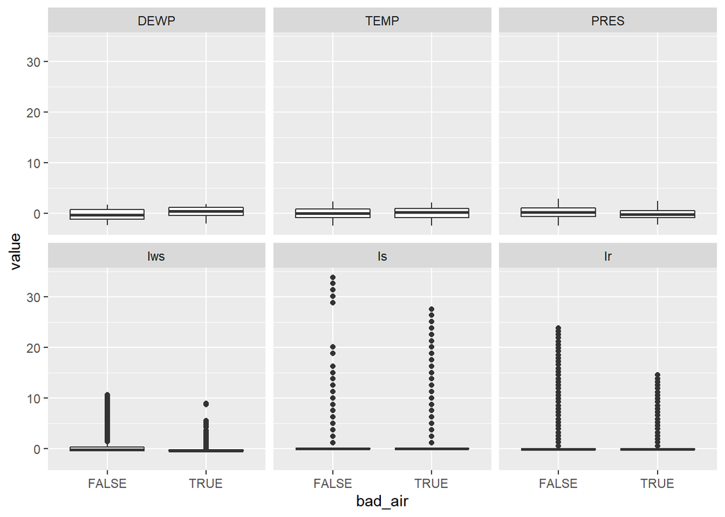

```r
ggplot(data = melting, aes(x=bad_air, y=value)) + geom_boxplot() + facet_wrap(~variable, ncol=3)
```

나머지 Is, Ir은 boxplot대비 아웃라이어가 너무 커 좋은 변수처럼 보이지는 않았다.

풍속의 경우도 확인을 해보자

```r
table(train$cbwd, train$bad_air)
```

```
##
##      FALSE TRUE
##   cv  2518 4370
##   NE  2212 1551
##   NW  7872 3186
##   SE  4409 6978
```

```r
prop.table(table(train$cbwd, train$bad_air), margin = 1)
```

```
##
##          FALSE      TRUE
##   cv 0.3655633 0.6344367
##   NE 0.5878289 0.4121711
##   NW 0.7118828 0.2881172
##   SE 0.3871959 0.6128041
```

학습 데이터에서 개략적으로

cv인 경우가 63%, SE경우 61%로 미세먼지 농도가 나쁨에 반해

이런 부분도 유의미하게 작용할 것으로 판단된다

고로 우선은

이슬점, 기압, 온도, 풍향, 풍속을 변수로 사용하여 예측을 시도해본다

```r
#d <- rpart(bad_air~DEWP+PRES+cbwd+TEMP+Iws, data = train, method = 'class', control = rpart.control(cp=0))
model_A <- rpart(bad_air~DEWP+PRES+cbwd+TEMP+Iws, data = train, method = 'class', control = rpart.control(cp=0))
pred_new <- predict(model_A, newdata=train, type='class')
mean(train$bad_air==pred_new)
```

```
## [1] 0.8323664
```

우선 학습 데이터에서는 이 모델이(필자가 시도해본 모델링 중) 가장 성능이 좋았다. 이를 모델 A로 설정하겠다.

해당 모델로 혼동 행렬을 그려보면

```r
tb1 <- table(pred_new, train$bad_air)
tb1
```

```
##
## pred_new FALSE  TRUE
##    FALSE 13980  2517
##    TRUE   3031 13568
```

precision은 0.81정도가 나왔고

```r
precision <- sum(tb1[2,2])/sum(tb1[2,])
precision
```

```
## [1] 0.8173986
```

recall은 0.84정도가 나왔고

```r
recall <- sum(tb1[2,2])/sum(tb1[,2])
recall
```

```
## [1] 0.8435188
```

```r
accuracy <- sum(diag(tb1))/sum(tb1)
accuracy
```

```
## [1] 0.8323664
```

F1 score는 0.83정도가 나왔다.

```r
f1 <- 2* {(precision*recall)/(precision+recall)}
f1
```

```
## [1] 0.8302533
```

Q3. Overfitting의 문제가 있을 수도 있어

test셋에서의 성능을 확인해보면

```r
pred_test <- predict(model_A, newdata=test, type='class')
mean(test$bad_air==pred_test)
```

```
## [1] 0.6738252
```

0.67로 기능이 확 줄어듦을 알 수 있다.

이는 어느 정도 과적합의 가능성이 있을 수 있음을 시사한다. 왜냐하면 학습 데이터에 비해 성능이 확연히 떨어지기 때문이다.

Q4.

과적합의 문제를 줄이는 과정을 들어가보자

우선 Pre & Post pruning 과정을 통해 어느 경우가 가장 적합한 minsplit이 되는 지를 모델의 내장 기능인 cptable을 통해 확인해본다

```r
tail(model_A$cptable)
```

```
##              CP nsplit rel error    xerror        xstd
## 80 1.776278e-05   1077 0.3456015 0.5266397 0.004935676
## 81 1.554243e-05   1084 0.3454772 0.5275101 0.004938348
## 82 1.243394e-05   1104 0.3451663 0.5275723 0.004938539
## 83 8.881389e-06   1114 0.3450420 0.5283183 0.004940825
## 84 7.771215e-06   1121 0.3449798 0.5285048 0.004941395
## 85 0.000000e+00   1129 0.3449176 0.5286913 0.004941966
```

이 경우 맨 마지막의 경우를 제외하고

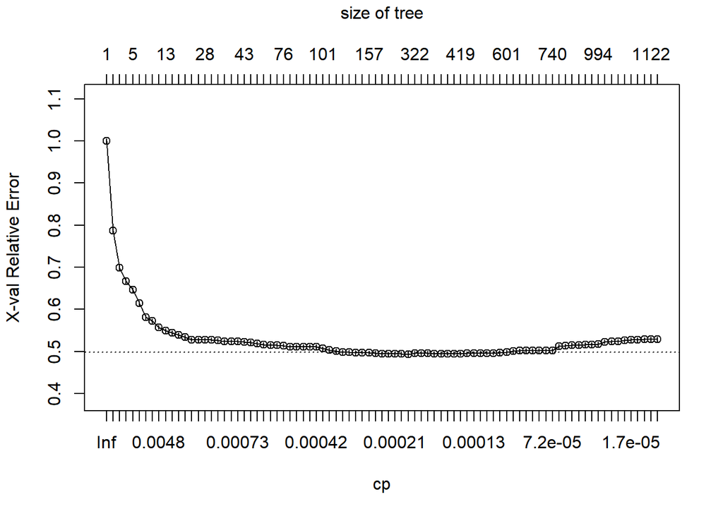

```r
plotcp(model_A)
```

```r
model_A_prune <- rpart(bad_air~DEWP+PRES+cbwd+TEMP+Iws, data = train, method = 'class', control = rpart.control(minsplit = 1129))
model_A_prune <- prune(model_A_prune, cp = 7.771215e-06)
```

split과 비슷하게 트리를 쪼개주는 method인 minbucket의 변화에 따라 어느 경우가 더 정확도가 높은 지를 확인해주는 반복문을 추가적으로 수행해보자

```r
score_test <- c()
for (i in 1:50){
  m <- rpart(bad_air~DEWP+PRES+cbwd+TEMP+Iws, data = train, method = 'class', control = rpart.control(cp = 7.771215e-06, minbucket =i, minsplit=1129))
  val_var <- predict(m, newdata = test, type = 'class')
  score_test <- c(score_test,mean(val_var == test$bad_air))
}
score_test
```

```
##  [1] 0.7023438 0.7023438 0.7023438 0.7023438 0.7023438 0.7023438 0.7023438
##  [8] 0.7023438 0.7023438 0.7023438 0.7023438 0.7023438 0.7023438 0.7023438
## [15] 0.7023438 0.7023438 0.7023438 0.7023438 0.7023438 0.7023438 0.7023438
## [22] 0.7023438 0.7023438 0.7023438 0.7023438 0.7023438 0.7023438 0.7023438
## [29] 0.7023438 0.7023438 0.7028057 0.7028057 0.7028057 0.7028057 0.7016511
## [36] 0.7016511 0.7026902 0.7026902 0.7026902 0.7026902 0.7026902 0.7016511
## [43] 0.7026902 0.7026902 0.7026902 0.7026902 0.7026902 0.7026902 0.7026902
## [50] 0.7026902
```

이러한 과적합 극복 모형을 가지고 모형을 조금 더 개선시켜보자

Q5.

```r
model_A_prune <- rpart(bad_air~DEWP+PRES+cbwd+TEMP+Iws, data = train, method = 'class', control = rpart.control(cp =  7.771215e-06, minsplit = 1129, minbucket = 50))
pred_adjust <- predict(model_A_prune,newdata = test,type = 'class')
mean(pred_adjust == test$bad_air)
```

```
## [1] 0.7026902
```

```r
pred_adjust_train <- predict(model_A_prune,newdata = train,type = 'class')
mean(pred_adjust_train==train$bad_air)
```

```
## [1] 0.7445311
```

물론 학습 데이터 내에서의 예측성은 줄었지만, 과적합을 많이 줄이고 test 데이터의 예측도를 높인 점에서 더 유의미한 결과가 나왔다고 판단할 수 있다.

이렇게 개선된 모델을 model B로 설정하자

```r
model_B <- model_A_prune
```

Q6. 최종적으로 구현된 모델을 가지고 혼동행렬을 구해보자

```r
prediction_final <- predict(model_B, newdata=test, type='class')
table(pred = prediction_final, actual = test$bad_air)
```

```
##        actual
## pred    FALSE TRUE
##   FALSE  2920  995
##   TRUE   1580 3166
```

이 경우

False Positive는 (2, 1)부분, 즉 1580개의 수치부분을 의미하는데

이는 실제로 미세먼지 농도가 나쁘다고 예측을 했는데 실제로 나쁘지 않았을 경우를 의미하고

False Negative는 (1, 2)부분, 즉 995개의 수치부분을 의미하는데

이는 실제로 미세먼지 농도가 나쁘지 않다고 예측을 했는데 실제로 나빴을 경우를 의미한다.

실제 사회적인 맥락을 고려하면, 미세먼지 농도가 나쁘다고 예측을 했는데 나쁘지 않는 경우는 사회적 cost가 크지 않지만 반면 나쁘지 않다고 예측을 했는데 실제로 나쁘게 되면 이에 대한 사회적 cost는 더 크게 된다. 왜냐하면 나쁘지 않다고 예측을 하여 대비하지 않고 있다가 손해를 보게 될 수 있기 때문이다.

따라서 이의 경우 precision 값이 감소하더라도 recall값을 늘리는 방향이 더 사회적인 맥락으로 적당하다고 볼 수 있다!!

model_B에 대해 각각의 ROCR커브를 그리기 위한 prediction 모형을 구축한다.

```r
TrainForROC <- predict(model_B, newdata=train, type = 'prob')[,2] # 이렇게 2번째 컬럼을 이용함을 인지!!
TestForROC <- predict(model_B, newdata=test, type = 'prob')[,2]
p1 <- prediction(TrainForROC, train$bad_air)
p2 <- prediction(TestForROC, test$bad_air)
```

학습 데이터의 ROCR의 경우

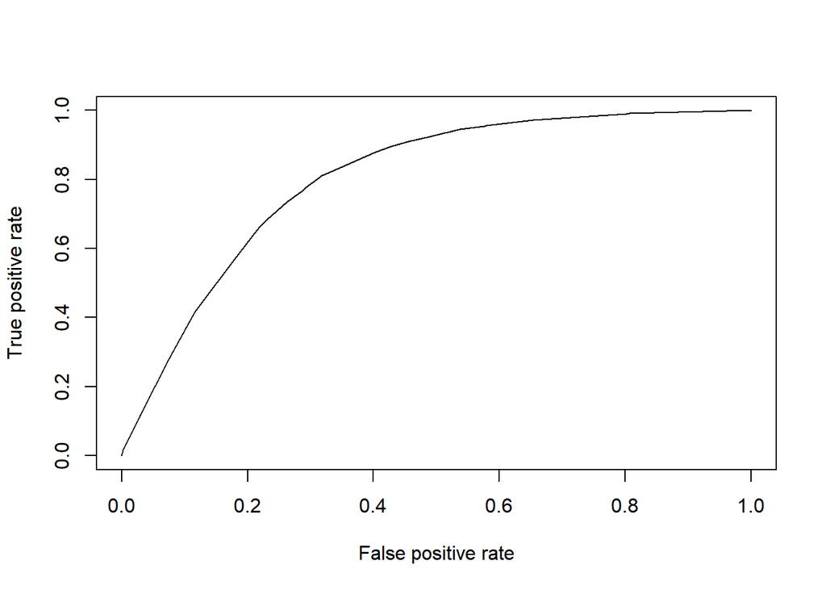

```r
plot(performance(p1, 'tpr', 'fpr'))
```

테스트 데이터의 ROCR의 경우

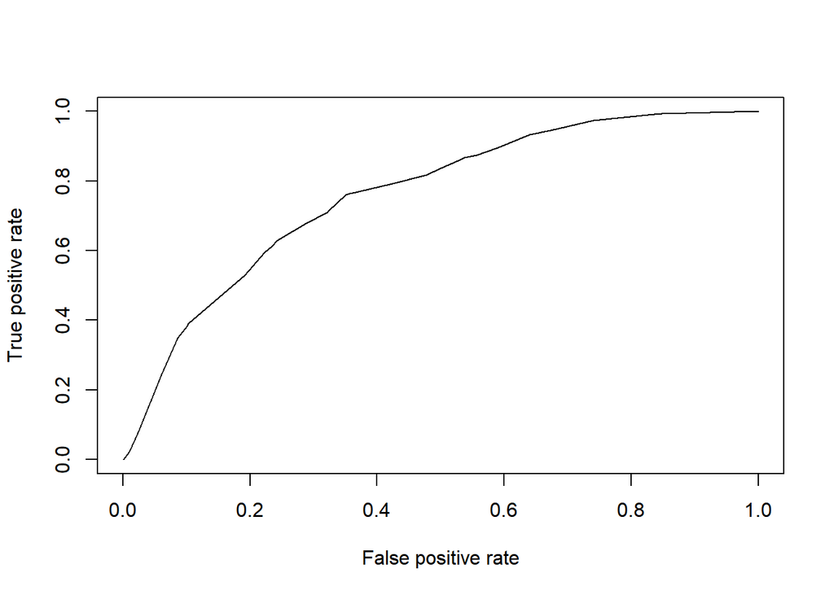

```r
plot(performance(p2, 'tpr', 'fpr'))
```

AUC의 경우

학습 데이터의 경우

```r
auc1<- performance(p1, 'auc')
auc1@y.values[[1]]
```

```
## [1] 0.8032757
```

```r
auc2 <- performance(p2, 'auc')
auc2@y.values[[1]]
```

```
## [1] 0.7607082
```

다음과 같이 나옴을 확인할 수 있다!!

## KNN

Q1. Knn을 쓰기 위해서는 변수가 연속형 변수일 경우 이를 표준화하는 작업이 필요, scale이 다르기 때문에 이러한 전처리를 거쳐준다.

학습, 테스트데이터를 나누기 전에 데이터셋에 표준화를해주는 작업을 거친다.

```r
# No행 제거
prs_scales <- prs[, -1]
```

```r
# 표준화 실시
prs_scales$DEWP <- scale(prs_scales$DEWP)
prs_scales$TEMP <- scale(prs_scales$TEMP)
prs_scales$PRES <- scale(prs_scales$PRES)
prs_scales$Iws <- scale(prs_scales$Iws)
```

풍향의 변수 경우 더미 변수이므로 one hot coding처리를 해준다.

```r
prs_scale <- predict(dummyVars(~cbwd, data=prs_scales), prs_scales)
prs_scale <- cbind(prs_scale, prs_scales)
head(prs_scale)
```

```
##    cbwd.cv cbwd.NE cbwd.NW cbwd.SE year month day hour pm2.5      DEWP
## 25       0       0       0       1 2010     1   2    0   129 -1.229777
## 26       0       0       0       1 2010     1   2    1   148 -1.160494
## 27       0       0       0       1 2010     1   2    2   159 -0.883364
## 28       0       0       0       1 2010     1   2    3   181 -0.606234
## 29       0       0       0       1 2010     1   2    4   138 -0.606234
## 30       0       0       0       1 2010     1   2    5   109 -0.606234
##         TEMP      PRES cbwd        Iws Is Ir bad_air
## 25 -1.347127 0.3453254   SE -0.4449388  0  0    TRUE
## 26 -1.347127 0.3453254   SE -0.4270016  0  0    TRUE
## 27 -1.429261 0.4424058   SE -0.4090643  0  0    TRUE
## 28 -1.429261 0.5394863   SE -0.3729883  1  0    TRUE
## 29 -1.429261 0.5394863   SE -0.3550511  2  0    TRUE
## 30 -1.511395 0.5394863   SE -0.3371139  3  0    TRUE
```

```r
# 학습 데이터와 훈련 데이터셋 나눔
train_k <- prs_scale[prs_scale$year != 2014, ]
test_k <- prs_scale[prs_scale$year == 2014, ]
head(train_k)
```

```
##    cbwd.cv cbwd.NE cbwd.NW cbwd.SE year month day hour pm2.5      DEWP
## 25       0       0       0       1 2010     1   2    0   129 -1.229777
## 26       0       0       0       1 2010     1   2    1   148 -1.160494
## 27       0       0       0       1 2010     1   2    2   159 -0.883364
## 28       0       0       0       1 2010     1   2    3   181 -0.606234
## 29       0       0       0       1 2010     1   2    4   138 -0.606234
## 30       0       0       0       1 2010     1   2    5   109 -0.606234
##         TEMP      PRES cbwd        Iws Is Ir bad_air
## 25 -1.347127 0.3453254   SE -0.4449388  0  0    TRUE
## 26 -1.347127 0.3453254   SE -0.4270016  0  0    TRUE
## 27 -1.429261 0.4424058   SE -0.4090643  0  0    TRUE
## 28 -1.429261 0.5394863   SE -0.3729883  1  0    TRUE
## 29 -1.429261 0.5394863   SE -0.3550511  2  0    TRUE
## 30 -1.511395 0.5394863   SE -0.3371139  3  0    TRUE
```

기압, 온도, 풍속, 이슬점과 같은 데이터에 표준화를 적용해준다

```r
# 예측 변수들을 기준으로 모형 구축 -- 날짜, pm2.5등의 불필요 데이터 제거
# 기존에 사용했던 변수들 중 가장 예측이 좋았던, 이슬점, 온도, 기압, 풍속 데이터로 비교한다.
train_k <- train_k[, c(1, 2, 3, 4,10,11,12,14,17)]
test_k <- test_k[, c(1,2,3,4,10,11,12,14,17)]
head(train_k)
```

```
##    cbwd.cv cbwd.NE cbwd.NW cbwd.SE      DEWP      TEMP      PRES        Iws
## 25       0       0       0       1 -1.229777 -1.347127 0.3453254 -0.4449388
## 26       0       0       0       1 -1.160494 -1.347127 0.3453254 -0.4270016
## 27       0       0       0       1 -0.883364 -1.429261 0.4424058 -0.4090643
## 28       0       0       0       1 -0.606234 -1.429261 0.5394863 -0.3729883
## 29       0       0       0       1 -0.606234 -1.429261 0.5394863 -0.3550511
## 30       0       0       0       1 -0.606234 -1.511395 0.5394863 -0.3371139
##    bad_air
## 25    TRUE
## 26    TRUE
## 27    TRUE
## 28    TRUE
## 29    TRUE
## 30    TRUE
```

따라서 train_k 데이터프레임에는 각 변수를 정규화한 변수들과 예측 값인 bad_air로 담겨져 있게 된다.

Q2. 우선 배운대로 관측치 수의 제곱근 값을 k로 취한다

```r
sqrt(nrow(train_k))
```

```
## [1] 181.9231
```

대략 180개 정도로 잡고 예측 모형을 돌린다

```r
knn.model1 <- knn(train = train_k[,-9], test = test_k[,-9], cl = train_k$bad_air, k = 180)
tb <- table(pred=knn.model1, test_k$bad_air)
tb
```

```
##
## pred    FALSE TRUE
##   FALSE  2772  773
##   TRUE   1728 3388
```

Accuracy는 대강 0.71정도 나오고

```r
mean(knn.model1==test_k$bad_air)
```

```
## [1] 0.7112343
```

precision의 경우 0.66

```r
pred <- sum(tb[2,2])/sum(tb[2,])
pred
```

```
## [1] 0.6622361
```

recall의 경우 0.81정도가 나왔다.

```r
rec <- sum(tb[2,2])/sum(tb[,2])
rec
```

```
## [1] 0.8142273
```

Q10. 교차검증을 이용하여 여러번 가장 좋은 k값의 범위를 찾아보니, 대강 20정도씩 변화시켜야 조금씩 정확도가 변하는 추이를 확인했다.

```r
grid <- expand.grid(.k = seq(100,300,by=20))
control <- trainControl(method = 'cv')

set.seed(2020)
train_k$bad_air <- as.factor(train_k$bad_air) #--- train.kknn 모델을 적용하기 위해 factor형 전환
test_k$bad_air <- as.factor(test_k$bad_air)

knn.trains <- train(bad_air~., data = train_k, method = 'knn', trControl = control, tuneGrid = grid)

train_k$bad_air <- as.logical(train_k$bad_air) #--- train.kknn 모델을 적용하기 위해 factor형 전환
test_k$bad_air <- as.logical(test_k$bad_air)
```

180을 기준으로 대략 k를 100부터 400까지 늘려가면서 그에 따른 accuracy, precision, recall, F1, AUC값을 추적하기 위해

k가 변할떄마다 각각의 값들을 계산해주는 for문을 구성한다.

```r
# 해당 값들이 들어가 있는 벡터 set
acc <- c()
pred <- c()
rec <- c()
F1 <- c()
Auc <- c()
```

```r
for(i in seq(100,400,by=20)){
  modeling <- knn(train = train_k[,-9], test = test_k[,-9], cl = train_k$bad_air, k = i, prob = T)
  tb <- table(pred=modeling, actual = test_k$bad_air)
  acc <- c(acc, sum(diag(tb))/sum(tb))
  pred <- c(pred, sum(tb[2,2])/sum(tb[2,]))
  rec <- c(rec, sum(tb[2,2])/sum(tb[,2]))
  F1 <- c(F1, 2*(acc*pred)/(acc+pred))
  testing <- ifelse(modeling == TRUE, attributes(modeling)$prob, 1-attributes(modeling)$prob)
  make_p <- prediction(testing, test_k$bad_air)
  acus <- performance(make_p, 'auc')
  Auc <- c(Auc, acus@y.values[[1]])
}
```

```r
k <- seq(100,400, by=20)
F1 <- 2*(pred*rec)/(pred+rec)
```

k변화에 따른 각 변수들의 변량을 확인해보면

1. accuracy의 경우

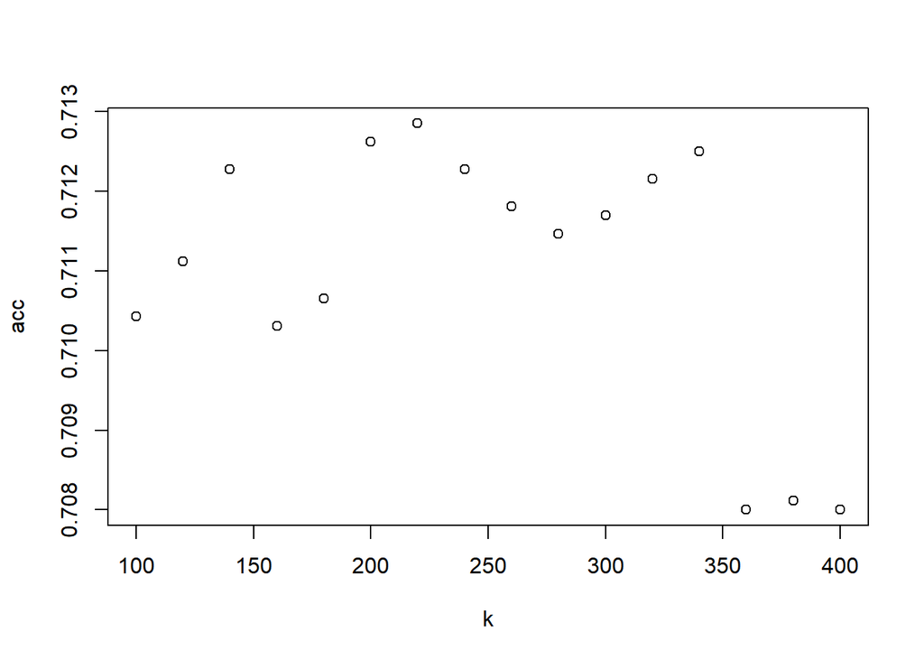

```r
plot(k, acc)
```

2. precision의 경우

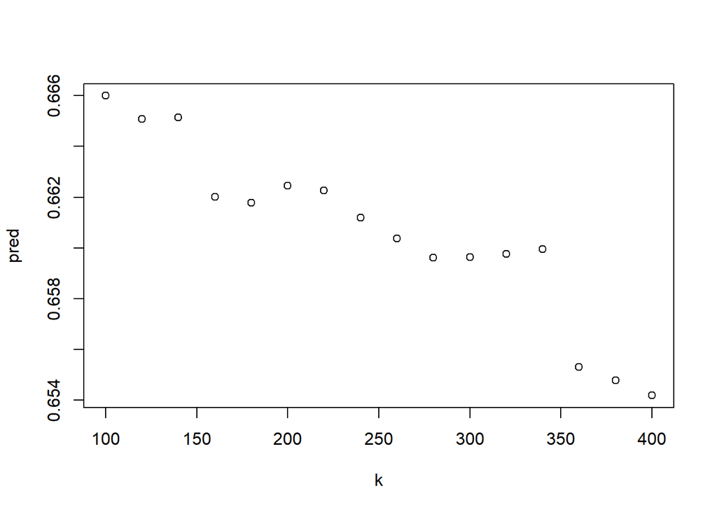

```r
plot(k, pred)
```

3. recall의 경우

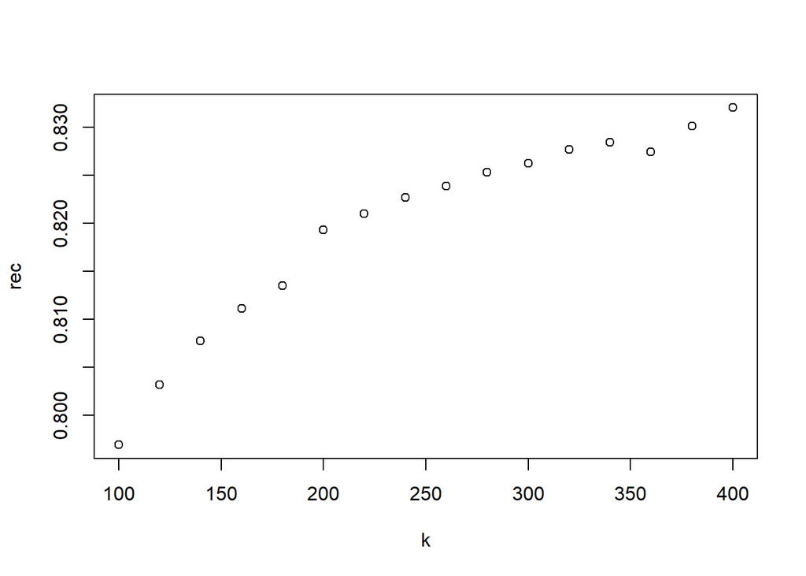

```r
plot(k, rec)
```

4) Auc의 경우

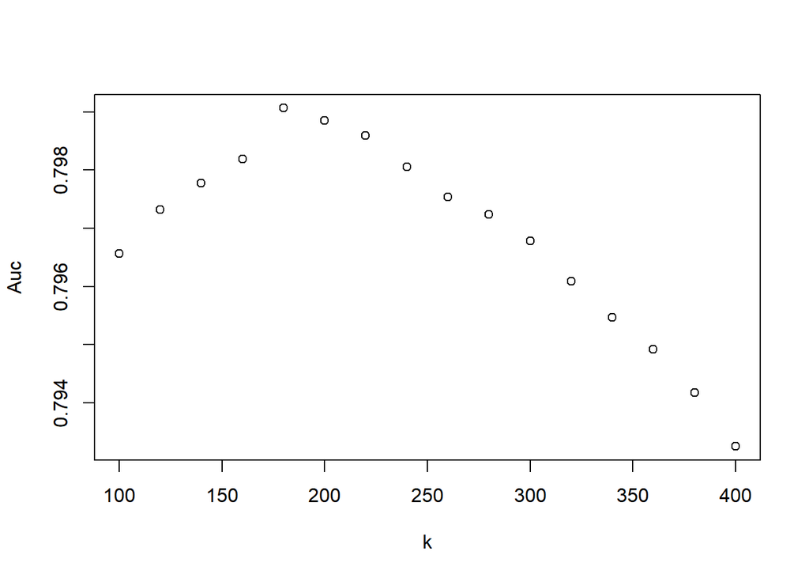

```r
plot(k, Auc)
```

5) F1 score의 경우

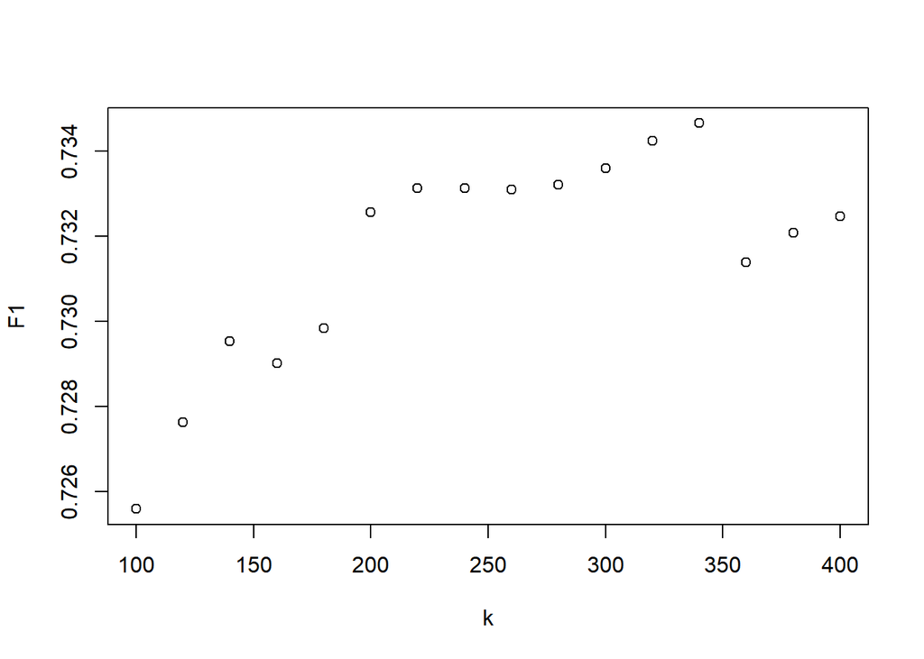

```r
plot(k, F1)
```

사실 어느 경우가 가장 값이 좋은지 이야기 하기가 어렵다

Accuracy나 AUC의 경우 100~200대가 값이 높았으나

F1 score나 recall의 경우 k가 클수록 값이 좋았고

precision은 그 반대의 결과가 나타났다.

우선 정확도랑 AUC가 높게 나온 200의 경우를 먼저 모델링을 돌려본다.

```r
final_model <- knn(train = train_k[,-9], test = test_k[,-9], cl = train_k$bad_air, k = 200)
table(final_model, test$bad_air)
```

```
##
## final_model FALSE TRUE
##       FALSE  2768  756
##       TRUE   1732 3405
```

```r
mean(final_model==test_k$bad_air)
```

```
## [1] 0.7127352
```

처음의 180보다 더 값이 개선됨을 확인할수 있다.

그 다음 recall과 F1 score가 높게 나온 300~400 언저리의 값을 가지고 와 본다

```r
final_model2 <- knn(train = train_k[,-9], test = test_k[,-9], cl = train_k$bad_air, k = 300)
table(final_model2, test$bad_air)
```

```
##
## final_model2 FALSE TRUE
##        FALSE  2723  721
##        TRUE   1777 3440
```

```r
mean(final_model2==test_k$bad_air)
```

```
## [1] 0.7115806
```

```r
final_model3 <- knn(train = train_k[,-9], test = test_k[,-9], cl = train_k$bad_air, k = 400)
table(final_model3, test$bad_air)
```

```
##
## final_model3 FALSE TRUE
##        FALSE  2671  702
##        TRUE   1829 3459
```

```r
mean(final_model3==test_k$bad_air)
```

```
## [1] 0.7077705
```

정확도는 줄지만 recall을 증가하게 하는 FN의 비중은 줄어듦을 확인할 수 있다.

Q11.

400보다 큰 수에서는 k가 너무 커져 knn을 실행 못하는 에러가 발생했었다.

100보다 작은 경우도 값이 더 좋아지는 경우는 없었다.

사실, 앞서 decision tree의 결과처럼

미세먼지 농도를 예측하는 맥락의 경우 FP보다는 FN의 경우가 더 cost가 크게 된다. 고로 precision값을 낮추는 한이

있어도 FN을 줄여야 하는 경우가 발생할 수 있다.

방법론적인 부분을 언급하면 수업 때 배운 내용을 참고하면

우선 model의 확률적인 method를 적용하여 (prob=T를 이용하여) 해당 True, False로 판단한 확률의 threshol값을 대략 파악해

True로 판단하는 threshold를 낮추어 precision을 낮추고 recall을 증가하는 방향을 생각해볼 수 있다!!

```r
prob.model <- knn(train = train_k[,-9], test = test_k[,-9], cl = train_k$bad_air, k = 200, prob=T)
head(prob.model)
```

```
## [1] FALSE FALSE FALSE FALSE TRUE  FALSE
## Levels: FALSE TRUE
```

```r
head(attributes(prob.model)$prob)
```

```
## [1] 0.975 0.975 0.975 0.975 0.675 0.605
```

이 경우 미세먼지 농도를 나쁨이라고 예측할 확률을 이용하여 확률값을 통일해준다

```r
testing <- ifelse(prob.model == TRUE, attributes(prob.model)$prob, 1-attributes(prob.model)$prob)
head(testing, 100)
```

```
##   [1] 0.02500000 0.02500000 0.02500000 0.02500000 0.67500000 0.39500000
##   [7] 0.23762376 0.21500000 0.19500000 0.13000000 0.08000000 0.06500000
##  [13] 0.06000000 0.05500000 0.04500000 0.05000000 0.03000000 0.02000000
##  [19] 0.02000000 0.37000000 0.55500000 0.62000000 0.81000000 0.59000000
##  [25] 0.68500000 0.73000000 0.72500000 0.69000000 0.68000000 0.87000000
##  [31] 0.91000000 0.80500000 0.84000000 0.88000000 0.76000000 0.71500000
##  [37] 0.68000000 0.64000000 0.64676617 0.63500000 0.63500000 0.72000000
##  [43] 0.75500000 0.79601990 0.83582090 0.88500000 0.82500000 0.85000000
##  [49] 0.75000000 0.78000000 0.75621891 0.78000000 0.79207921 0.76000000
##  [55] 0.66500000 0.48000000 0.50500000 0.21000000 0.10000000 0.07462687
##  [61] 0.07500000 0.05500000 0.08000000 0.10000000 0.30500000 0.32000000
##  [67] 0.35000000 0.32178218 0.39800995 0.60500000 0.71000000 0.83500000
##  [73] 0.87562189 0.88000000 0.85643564 0.89500000 0.82089552 0.82178218
##  [79] 0.82000000 0.90000000 0.90099010 0.91089109 0.89500000 0.89000000
##  [85] 0.80099502 0.81500000 0.80500000 0.79000000 0.75000000 0.78109453
##  [91] 0.85000000 0.86000000 0.86000000 0.85572139 0.85643564 0.83582090
##  [97] 0.86500000 0.80500000 0.88000000 0.83500000
```

맞다고 예측하는 threshold가 기존 default인 0.5에서 더 낮추어 0.3까지 낮추어본다.

```r
threshold <- 0.3
prob.test <- ifelse(testing > 0.3, TRUE, FALSE)
final_tb <- table(prob.test, test$bad_air)
final_tb
```

```
##
## prob.test FALSE TRUE
##     FALSE  1671  175
##     TRUE   2829 3986
```

이를 기존의 table과 비교를 해보면

```r
table(final_model, test$bad_air)
```

```
##
## final_model FALSE TRUE
##       FALSE  2768  756
##       TRUE   1732 3405
```

전반적으로 FP의 비율은 늘었지만 그만큼 FN의 비중은 더 감소함을 확인할 수 있다.